# COVID-19_data_analysis

**COVID-19 Global Data Analysis**

**Data Source:** [European Centre for Disease Prevention and Control](https://www.ecdc.europa.eu/en/publications-data/download-todays-data-geographic-distribution-covid-19-cases-worldwide)

```python
import datetime
import os
import json
import pandas as pd
import numpy as np
import matplotlib.pyplot as plt
import geopandas as gpd
from shapely.geometry import Point, Polygon
from jupyterthemes import jtplot

%matplotlib inline

jtplot.style()

os.chdir('C:\\Users\\rickey\\Desktop\\jupyter_nb')
```

**Time Stamp**

```python
print(f'{datetime.datetime.now()} US/Pacific')
```

```
2020-06-08 13:33:32.087536 US/Pacific
```

**Download latest data, save and print a sample**

```python
covid_data_df = pd.read_csv(
    'https://opendata.ecdc.europa.eu/covid19/casedistribution/csv'
)
covid_data_df.to_csv(
    'ecdc_covid_data.csv', index=False, mode='w', na_rep='NaN'
)
# covid_data_df = pd.read_csv('ecdc_covid_data.csv')
covid_data_df.head()
```

|  | dateRep | day | month | year | cases | deaths | countriesAndTerritories | geoId | countryterritoryCode | popData2018 | continentExp |
| --- | --- | --- | --- | --- | --- | --- | --- | --- | --- | --- | --- |
| 0 | 08/06/2020 | 8 | 6 | 2020 | 791 | 30 | Afghanistan | AF | AFG | 37172386.0 | Asia |
| 1 | 07/06/2020 | 7 | 6 | 2020 | 582 | 18 | Afghanistan | AF | AFG | 37172386.0 | Asia |
| 2 | 06/06/2020 | 6 | 6 | 2020 | 915 | 9 | Afghanistan | AF | AFG | 37172386.0 | Asia |
| 3 | 05/06/2020 | 5 | 6 | 2020 | 787 | 6 | Afghanistan | AF | AFG | 37172386.0 | Asia |
| 4 | 04/06/2020 | 4 | 6 | 2020 | 758 | 24 | Afghanistan | AF | AFG | 37172386.0 | Asia |

**Convert date column, some assign global variables and create a function**

```python
covid_data_df['dateRep'] = (
    pd.to_datetime(covid_data_df['dateRep'], format='%d/%m/%Y').dt.date
)

covid_dates = list(sorted(covid_data_df['dateRep'].unique()))
one_day = datetime.timedelta(days=1)


def autolabel(rects):
    """Attach a text label above each bar in *rects*, displaying its
       height."""
    for rect in rects:
        height = rect.get_height()
        ax.annotate(
            '{}'.format(height),
            xy=(rect.get_x() + rect.get_width() / 2, height),
            xytext=(0, 0),
            textcoords="offset points",
            ha='center', va='bottom'
        )


print(f'Most recent date in file: {covid_data_df["dateRep"].max()}')
```

```
Most recent date in file: 2020-06-08
```

**Data sample**

```python
covid_data_df.head()
```

|  | dateRep | day | month | year | cases | deaths | countriesAndTerritories | geoId | countryterritoryCode | popData2018 | continentExp |
| --- | --- | --- | --- | --- | --- | --- | --- | --- | --- | --- | --- |
| 0 | 2020-06-08 | 8 | 6 | 2020 | 791 | 30 | Afghanistan | AF | AFG | 37172386.0 | Asia |
| 1 | 2020-06-07 | 7 | 6 | 2020 | 582 | 18 | Afghanistan | AF | AFG | 37172386.0 | Asia |
| 2 | 2020-06-06 | 6 | 6 | 2020 | 915 | 9 | Afghanistan | AF | AFG | 37172386.0 | Asia |
| 3 | 2020-06-05 | 5 | 6 | 2020 | 787 | 6 | Afghanistan | AF | AFG | 37172386.0 | Asia |
| 4 | 2020-06-04 | 4 | 6 | 2020 | 758 | 24 | Afghanistan | AF | AFG | 37172386.0 | Asia |

**Reduce the name length of some countires, makes plotting look better**

```python
covid_data_df.loc[covid_data_df['countriesAndTerritories'] ==
                  'United_States_of_America',
                  'countriesAndTerritories'] = 'USA'


covid_data_df.loc[covid_data_df['countriesAndTerritories'] ==
                  'United_Kingdom', 'countriesAndTerritories'] = 'UK'
```

**Create dataframes for top 10 countries with highest number of deaths**

```python
top_10_dict = {}
top_10_dict = (
    covid_data_df.groupby(['countryterritoryCode'])['deaths'].sum()
    .sort_values(ascending=False).iloc[0:10].to_dict()
)
top_10_dict
```

```
{'USA': 110514,
 'GBR': 40542,
 'BRA': 35930,
 'ITA': 33899,
 'FRA': 29155,
 'ESP': 27136,
 'MEX': 13699,
 'BEL': 9595,
 'DEU': 8674,
 'IRN': 8281}
```

```python
top_10_by_deaths = {}
for country in top_10_dict:
    country_code = (
        covid_data_df[covid_data_df['countryterritoryCode'] == country]
        ['countryterritoryCode'].iloc[0]
    )
    top_10_by_deaths[country_code] = (
        covid_data_df[covid_data_df['countryterritoryCode'] == country]
        .sort_values(by=['dateRep'])
    )
```

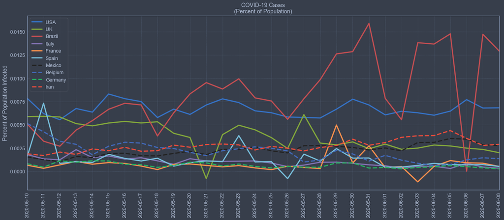

```python
fig, ax = plt.subplots(figsize=(18, 8))
x = np.arange(len(top_10_by_deaths['USA']['cases'].iloc[-30:]))

count = 0
for country in top_10_by_deaths:
    if count < 6:
        ax.plot(
            x, (top_10_by_deaths[country]['cases'].iloc[-30:] /
                top_10_by_deaths[country]['popData2018'].iloc[-30:]) *
            100, label=top_10_by_deaths[country]
            ['countriesAndTerritories'].iloc[0], linewidth=3
        )
    else:
        ax.plot(
            x, (top_10_by_deaths[country]['cases'].iloc[-30:] /
                top_10_by_deaths[country]['popData2018'].iloc[-30:]) *
            100, label=top_10_by_deaths[country]
            ['countriesAndTerritories'].iloc[0], linewidth=3,
            linestyle='dashed'
        )
    count += 1

ax.set(
    ylabel="Percent of Population Infected",
    title="COVID-19 Cases\n(Percent of Population)"
)
ax.set_xticklabels(
    np.arange(min(covid_dates[-30:]), max(covid_dates[-30:]) + one_day,
              step=1), rotation=90
)
ax.set_xticks(np.arange(min(x), max(x) + 1, step=1))

ax.margins(x=0)
ax.grid(linestyle='--', linewidth=0.5)
plt.legend(loc=2)
plt.tight_layout()
plt.show()
```

**Plot top 10 countries with highest number of deaths by percent of population**

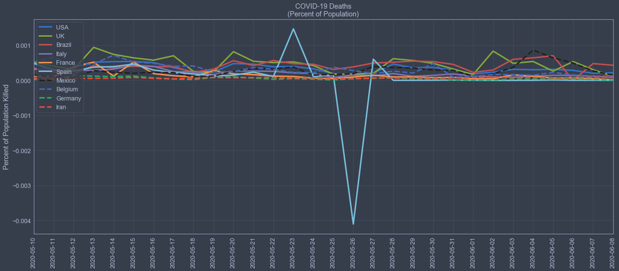

```python
fig, ax = plt.subplots(figsize=(18, 8))
x = np.arange(len(list(top_10_by_deaths['USA']['deaths'].iloc[-30:])))

count = 0
for country in top_10_by_deaths:
    if count < 6:
        ax.plot(
            x, (top_10_by_deaths[country]['deaths'].iloc[-30:] /
                top_10_by_deaths[country]['popData2018'].iloc[-30:]) *
            100, label=top_10_by_deaths[country]
            ['countriesAndTerritories'].iloc[0], linewidth=3
        )
    else:
        ax.plot(
            x, (top_10_by_deaths[country]['deaths'].iloc[-30:] /
                top_10_by_deaths[country]['popData2018'].iloc[-30:]) *
            100, label=top_10_by_deaths[country]
            ['countriesAndTerritories'].iloc[0], linewidth=3,
            linestyle='dashed'
        )
    count += 1

ax.set(
    ylabel="Percent of Population Killed",
    title="COVID-19 Deaths\n(Percent of Population)"
)
ax.set_xticklabels(
    np.arange(min(covid_dates[-30:]), max(covid_dates[-30:]) + one_day,
              step=1), rotation=90
)
ax.set_xticks(np.arange(min(x), max(x) + 1, step=1))

ax.margins(x=0)
ax.grid(linestyle='--', linewidth=0.5)
plt.legend(loc=2)
plt.tight_layout()
plt.show()
```

**Plot number of cases for top 10 countries**

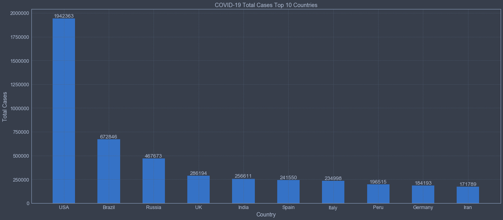

```python
cases_dict = (
    dict(covid_data_df.groupby(['countriesAndTerritories'])
         ['cases'].sum().sort_values(ascending=False).iloc[0:10])
)
labels = [country for country in cases_dict.keys()]
cases = [case for case in cases_dict.values()]

fig, ax = plt.subplots(figsize=(18, 8))
x = np.arange(len(labels))

rects = ax.bar(x, cases, width=0.5)

autolabel(rects)
ax.set_title(label='COVID-19 Total Cases Top 10 Countries')
ax.set(xlabel="Country", ylabel="Total Cases")
ax.set_xticklabels(labels)
ax.set_xticks(x)
ax.grid(linestyle='--', linewidth=0.5)
plt.tight_layout()
plt.show()
```

**Plot number of deaths for top 10 countries**

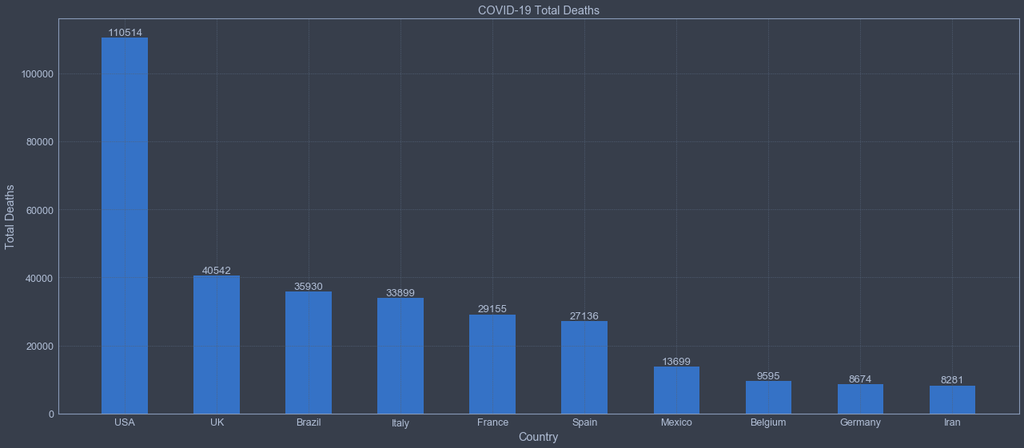

```python
deaths_dict = (
    dict(covid_data_df.groupby(['countriesAndTerritories'])
         ['deaths'].sum().sort_values(ascending=False).iloc[0:10])
)
labels = [country for country in deaths_dict.keys()]
deaths = [death for death in deaths_dict.values()]

fig, ax = plt.subplots(figsize=(18, 8))
x = np.arange(len(labels))

rects = ax.bar(x, deaths, width=0.5)

autolabel(rects)

ax.set(
    xlabel="Country", ylabel="Total Deaths", title="COVID-19 Total Deaths"
)
ax.set_xticklabels(labels)
ax.set_xticks(x)
ax.grid(linestyle='--', linewidth=0.5)
plt.tight_layout()
plt.show()
```

**Plot total cases globally for last 30 days**

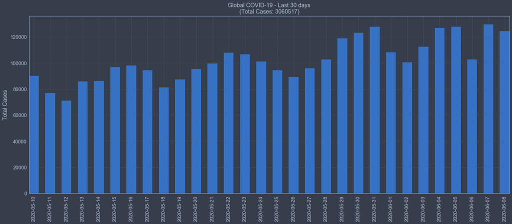

```python
fig, ax = plt.subplots(figsize=(18, 8))

cases = covid_data_df.groupby(['dateRep'])['cases'].sum().iloc[-30:]
x = np.arange(len(covid_dates[-30:]))

ax.bar(x, cases, width=0.6)
ax.set(
    ylabel="Total Cases",
    title=f"Global COVID-19 - Last 30 days\n(Total Cases: {cases.sum()})"
)
ax.set_xticklabels(
    np.arange(min(covid_dates[-30:]), max(covid_dates[-30:]) + one_day,
              step=1), rotation=90
)
ax.set_xticks(np.arange(min(x), max(x) + 1, step=1))

ax.margins(x=0)
ax.grid(linestyle='--', linewidth=0.5)
plt.tight_layout()
plt.show()
```

**Plot total deaths globally for last 30 day**

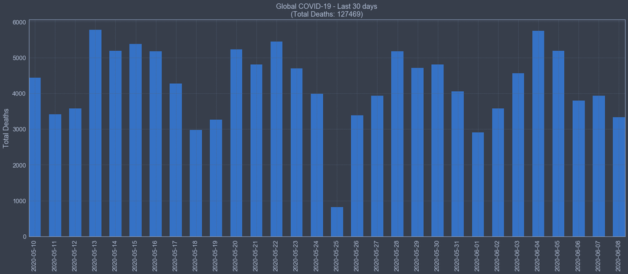

```python
fig, ax = plt.subplots(figsize=(18, 8))

covid_deaths_global = (
    covid_data_df.groupby(['dateRep'])['deaths'].sum().iloc[-30:]
)
x = np.arange(len(covid_dates[-30:]))

ax.bar(x, covid_deaths_global, width=0.6)
ax.set(
    ylabel="Total Deaths",
    title="Global COVID-19 - Last 30 days\n(Total Deaths: "
    f"{covid_deaths_global.sum()})"
)

ax.set_xticklabels(
    np.arange(min(covid_dates[-30:]), max(covid_dates[-30:]) + one_day,
              step=1), rotation=90
)
ax.set_xticks(np.arange(min(x), max(x) + 1, step=1))
ax.grid(linestyle='--', linewidth=0.5)
ax.margins(x=0)
plt.tight_layout()
plt.show()
```

**Plot total USA cases and death**

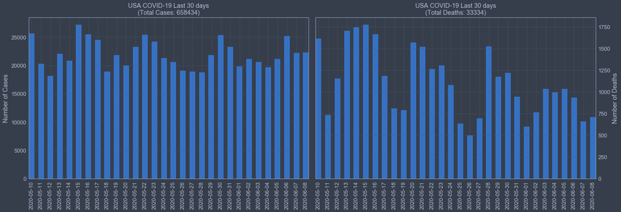

```python
fig, (ax1, ax2) = plt.subplots(1, 2, figsize=(20, 7))
x = np.arange(
    len(list(top_10_by_deaths['USA']['dateRep'].iloc[-30:]))
)

ax1.bar(
    x, list(top_10_by_deaths['USA']['cases'].iloc[-30:]),
    label=top_10_by_deaths['USA']['countriesAndTerritories'].iloc[0],
    width=0.6
)
us_cases_sum = top_10_by_deaths['USA']['cases'].iloc[-30:].sum()
ax1.set(ylabel="Number of Cases",
        title=f"USA COVID-19 Last 30 days\n(Total Cases: {us_cases_sum})")
ax1.set_xticklabels(
    np.arange(min(covid_dates[-30:]), max(covid_dates[-30:]) + one_day,
              step=1), rotation=90
)
ax1.set_xticks(np.arange(min(x), max(x) + 1, step=1))

ax2.bar(
    x, list(top_10_by_deaths['USA']['deaths'].iloc[-30:]),
    label=top_10_by_deaths['USA']['countriesAndTerritories'].iloc[0],
    width=0.6
)

us_deaths_sum = top_10_by_deaths['USA']['deaths'].iloc[-30:].sum()
ax2.set(
    ylabel="Number of Deaths", title="USA "
    f"COVID-19 Last 30 days\n(Total Deaths: {us_deaths_sum})"
)
ax2.set_xticklabels(
    np.arange(min(covid_dates[-30:]), max(covid_dates[-30:]) + one_day,
              step=1), rotation=90
)
ax2.set_xticks(np.arange(min(x), max(x) + 1, step=1))

ax2.tick_params(labelright=True, labelleft=False)
ax2.yaxis.set_label_position("right")
ax1.margins(x=0)
ax2.margins(x=0)
ax1.grid(linestyle='--', linewidth=0.5)
ax2.grid(linestyle='--', linewidth=0.5)
plt.tight_layout()
plt.show()
```

**COVID-19 Data Analysis by US County**

**Data Source:** [New York Times GITHUB](https://raw.githubusercontent.com/nytimes/covid-19-data/master/us-counties.csv)

**Download data to a dataframe**

```python
us_county_url = (
    'https://raw.githubusercontent.com/nytimes/covid-19-data/'
    'master/us-counties.csv'
)
us_counties_df = pd.read_csv(us_county_url)
us_counties_df.to_csv(
    'nyt_us_county.csv', index=False, mode='w', na_rep='NaN'
)
```

**Convert state name to state abbreviation**

```python
with open('states.json', 'r') as fh:
    states = json.load(fh)

for state in states:
    us_counties_df.loc[us_counties_df['state'] ==
                       state, 'state'] = states[state]
```

**Convert date column**

```python
us_counties_df['date'] = (
    pd.to_datetime(us_counties_df['date'], format='%Y-%m-%d').dt.date
)
```

**Check most recent date in file**

```python
print(us_counties_df['date'].max())
```

```
2020-06-07
```

**Data sample**

```python
us_counties_df.head()
```

|  | date | county | state | fips | cases | deaths |
| --- | --- | --- | --- | --- | --- | --- |
| 0 | 2020-01-21 | Snohomish | WA | 53061.0 | 1 | 0 |
| 1 | 2020-01-22 | Snohomish | WA | 53061.0 | 1 | 0 |
| 2 | 2020-01-23 | Snohomish | WA | 53061.0 | 1 | 0 |
| 3 | 2020-01-24 | Cook | IL | 17031.0 | 1 | 0 |
| 4 | 2020-01-24 | Snohomish | WA | 53061.0 | 1 | 0 |

**Define some functions**

```python
def align_yaxis(ax1, v1, ax2, v2):
    """adjust ax2 ylimit so that v2 in ax2 is aligned to v1 in ax1"""
    _, y1 = ax1.transData.transform((0, v1))
    _, y2 = ax2.transData.transform((0, v2))
    inv = ax2.transData.inverted()
    _, dy = inv.transform((0, 0)) - inv.transform((0, y1-y2))
    miny, maxy = ax2.get_ylim()
    ax2.set_ylim(miny+dy, maxy+dy)


def autolabel(rects):
    """Attach a text label above each bar in *rects*, displaying its
       height."""
    for rect in rects:
        height = rect.get_height()
        ax.annotate(
            f"{height}",
            xy=(rect.get_x() + rect.get_width() / 2, height),
            xytext=(0, 0),
            textcoords="offset points",
            ha='center', va='bottom'
        )
```

```python
def plot_county(cname, df, ytick_step):
    """Returns matplotlib plot object for a given county

    Args: cname - the county name, string
          df - the dataframe with the per county data
          ytick_step - int used to adjust yticks"""

    county_df = (
        df[df['county'] == cname].iloc[-30:].sort_values(by=['date'])
    )
    county_tot = (
        df[df['county'] == cname].iloc[-30:].groupby(['county'])['cases']
        .max()[0]
    )
    county_deaths = (
        df[df['county'] == cname].iloc[-30:].groupby(['county'])['deaths']
        .max()[0]
    )

    fig, ax = plt.subplots(figsize=(18, 8))
    x = np.arange(len(county_df['date']))

    ax.bar(x, county_df['cases'], label='Cases', width=0.6)
    ax.set(
        xlabel="Days", ylabel="Total Cases",
        title=f"{cname} County COVID-19\nTotal Cases: {county_tot}\n"
        f"Total Deaths: {county_deaths}"
    )
    ax.set_xticklabels(
        np.arange(min(county_df['date']), max(county_df['date']) +
                  datetime.timedelta(days=1), step=1), rotation=90
    )
    ax.set_xticks(np.arange(min(x), max(x) + 1, step=1))
    ax.grid(linestyle='--', linewidth=0.5)

    ax2 = ax.twinx()
    ax2.plot(x, county_df['deaths'], label='Deaths', color='r', linewidth=3)
    ax2.set(ylabel='Total Deaths')
    ax2.set_yticks(range(0, max(county_df['deaths']) + 1, ytick_step))

    ax.set_yticks(
        np.linspace(int(ax.get_yticks()[0]), int(ax.get_yticks()[-1]),
                    len(ax2.get_yticks()))
    )

    ax2.grid(b=False)
    h1, l1 = ax.get_legend_handles_labels()
    h2, l2 = ax2.get_legend_handles_labels()
    ax.legend(h1 + h2, l1 + l2, loc=2)

    align_yaxis(ax, 0, ax2, 0)
    ax.margins(x=0)
    plt.tight_layout()

    return plt
```

**Maricopa County, Arizona**

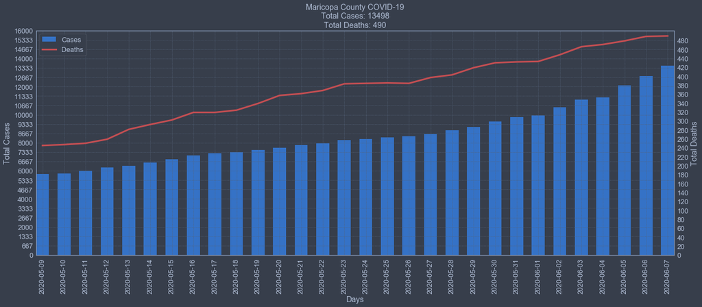

```python
maricopa_plt = plot_county('Maricopa', us_counties_df, 20)
maricopa_plt.show()
```

**Contra Costa County, California**

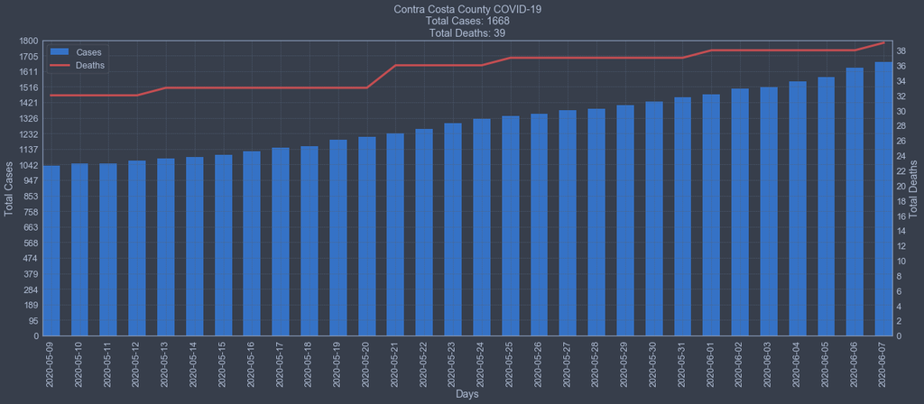

```python
contra_costa_plt = plot_county('Contra Costa', us_counties_df, 2)
contra_costa_plt.show()
```

**Amador County, California**

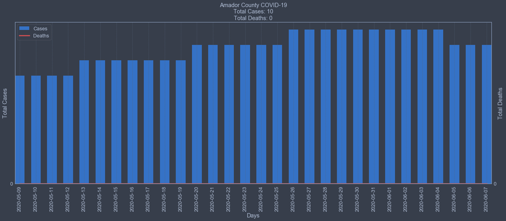

```python
amador_plt = plot_county('Amador', us_counties_df, 2)
amador_plt.show()
```

**Marin County, California**

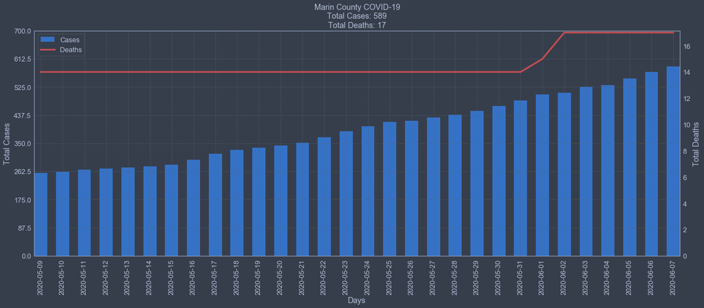

```python
marin_plt = plot_county('Marin', us_counties_df, 2)
marin_plt.show()
```

**Dalas County, Texas**

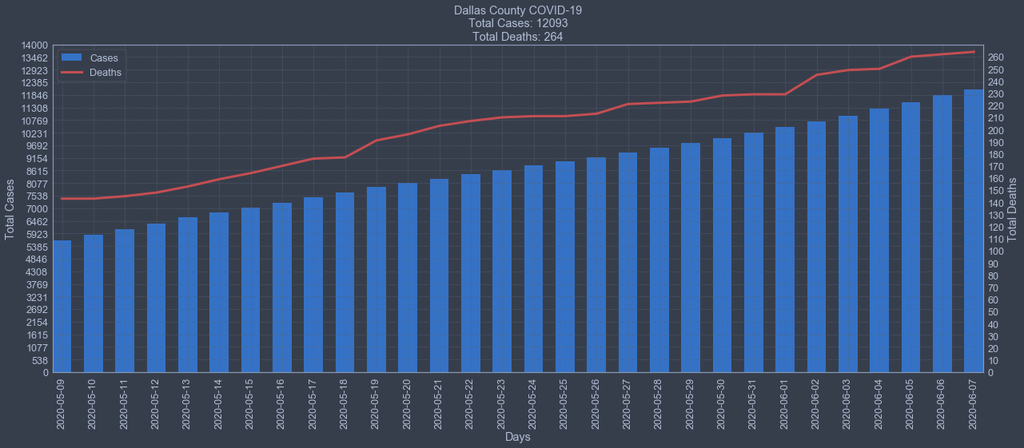

```python
# I couldn't use the plot_county function due to Dallas county having
# multiple entires in the FIPS file.  Need to fix this.
dallas_df = (
    us_counties_df[us_counties_df['fips'] == 48113].iloc[-30:]
    .sort_values(by=['date'])
)
dallas_tot = (
    us_counties_df[us_counties_df['fips'] ==
                   48113].iloc[-30:].groupby(['county'])['cases'].max()[0]
)
dallas_deaths = (
    us_counties_df[us_counties_df['fips'] ==
                   48113].iloc[-30:].groupby(['county'])['deaths'].max()[0]
)

fig, ax = plt.subplots(figsize=(18, 8))
x = np.arange(len(dallas_df['date']))

ax.bar(x, dallas_df['cases'], label='Cases', width=0.6)
ax.set(
    xlabel="Days",
    ylabel="Total Cases",
    title=f"Dallas County COVID-19\nTotal Cases: {dallas_tot}\n"
    f"Total Deaths: {dallas_deaths}"
)
ax.set_xticklabels(
    np.arange(min(dallas_df['date']),
              max(dallas_df['date']) + datetime.timedelta(days=1), step=1),
    rotation=90
)
ax.set_xticks(np.arange(min(x), max(x)+1, step=1))
ax.grid(linestyle='--', linewidth=0.5)

ax2 = ax.twinx()
ax2.plot(x, dallas_df['deaths'], label='Deaths', color='r', linewidth=3)
ax2.set(ylabel='Total Deaths')
ax2.set_yticks(range(0, max(dallas_df['deaths'])+1, 10))
ax.set_yticks(
    np.linspace(int(ax.get_yticks()[0]), int(ax.get_yticks()[-1]),
                len(ax2.get_yticks()))
)
ax2.grid(b=False)

h1, l1 = ax.get_legend_handles_labels()
h2, l2 = ax2.get_legend_handles_labels()
ax.legend(h1+h2, l1+l2, loc=2)

align_yaxis(ax, 0, ax2, 0)

ax.margins(x=0)
plt.tight_layout()
plt.show()
```

**Top 20 US County - Cases**

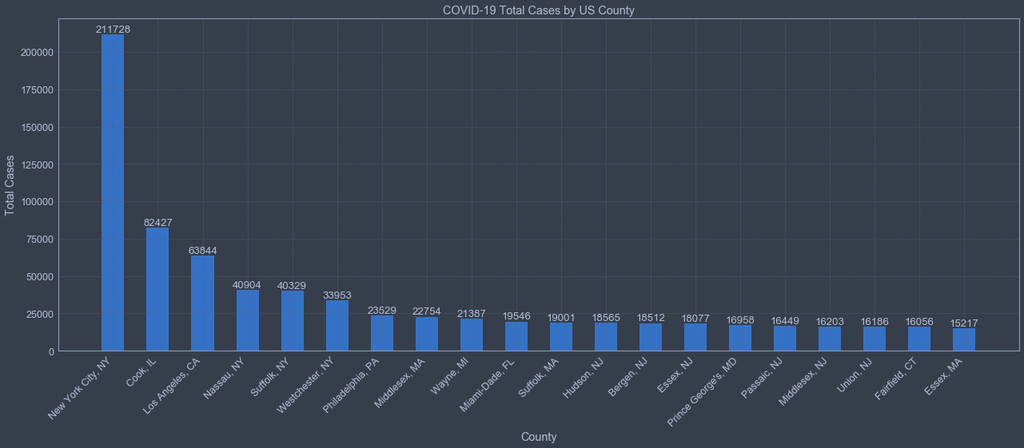

```python
cases_dict = (
    dict(us_counties_df.groupby(['county', 'state'])
         ['cases'].max().sort_values(ascending=False).iloc[0:20])
)
labels = [f'{tup[0]}, {tup[1]}' for tup in cases_dict.keys()]
cases = [case for case in cases_dict.values()]

fig, ax = plt.subplots(figsize=(18, 8))

x = np.arange(len(labels))

rects = ax.bar(x, cases, width=0.5)

autolabel(rects)

ax.set(xlabel="County", ylabel="Total Cases",
       title="COVID-19 Total Cases by US County")
ax.set_xticklabels(labels, rotation=45, ha='right')
ax.set_xticks(x)
ax.grid(linestyle='--', linewidth=0.5)
plt.tight_layout()
plt.show()
```

**Top 20 US County - Deaths**

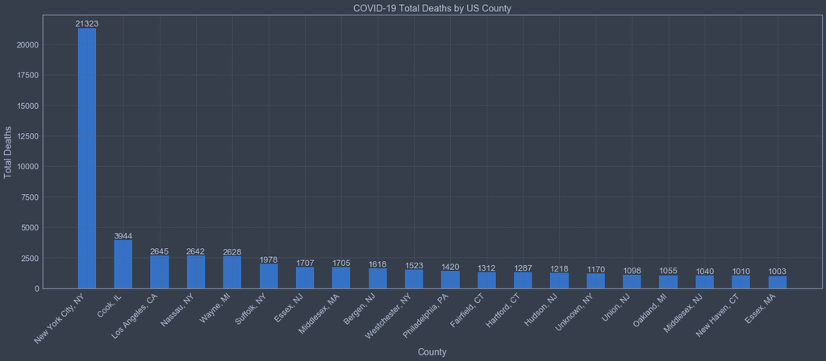

```python
deaths_dict = (
    dict(us_counties_df.groupby(['county', 'state'])
         ['deaths'].max().sort_values(ascending=False).iloc[0:20])
)
labels = [f'{tup[0]}, {tup[1]}' for tup in deaths_dict.keys()]
deaths = [case for case in deaths_dict.values()]

fig, ax = plt.subplots(figsize=(18, 8))
x = np.arange(len(labels))

rects = ax.bar(x, deaths, width=0.5)

autolabel(rects)

ax.set(xlabel="County", ylabel="Total Deaths",
       title="COVID-19 Total Deaths by US County")
ax.set_xticklabels(labels, rotation=45, ha='right')
ax.set_xticks(x)
ax.grid(linestyle='--', linewidth=0.5)
plt.tight_layout()
plt.show()
```

**Create geopandas DataFrame with county longitude and latitude data**

```python
counties_gdf = gpd.read_file('counties/c_03mr20.shp')
counties_gdf.crs = 'epsg:4326'
counties_gdf.drop_duplicates(inplace=True)
counties_gdf = counties_gdf.astype({'FIPS': 'float'})
```

**Combine DataFrame containing COVID-19 data with DataFrame containing longitude and latitude data**

```python
us_counties_df = us_counties_df[
    (us_counties_df['state'] != 'AK') & (us_counties_df['state'] != 'HI')
]

us_counties_grouped_df = (
    us_counties_df.groupby(['county', 'state', 'fips'])
    [['cases', 'deaths']].sum().reset_index(level=[0, 1, 2])
)

us_county_data_geo_df = pd.merge(
    us_counties_grouped_df, counties_gdf, left_on='fips', right_on='FIPS',
    how='left'
)
```

**Plot conitintal US map with top N cases by county**

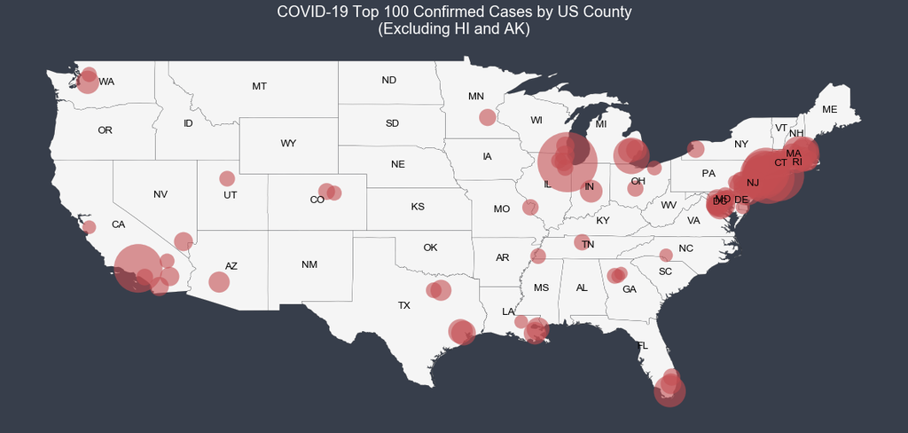

```python
points = us_county_data_geo_df.apply(
    lambda row: Point(row['LON'], row['LAT']), axis=1
)
geo_county_points = gpd.GeoDataFrame(us_county_data_geo_df, geometry=points)
geo_county_points.crs = 'epsg:4326'  # 4269, 9075, 4326
geo_county_points = geo_county_points.sort_values(
    by=['cases'], ascending=False
)
topn = 100

states_gdf = gpd.read_file('states/states.shp')
states_gdf.crs = 'epsg:4326'

fig, ax = plt.subplots(figsize=(18, 8))

ax.set_aspect('equal')
ax.set_title(f"COVID-19 Top {topn} Confirmed Cases by US County\n"
             f"(Excluding HI and AK)", fontsize=20, color='w')
ax.set_axis_off()

(
    states_gdf[(states_gdf['STATE_NAME'] != 'Alaska') &
               (states_gdf['STATE_NAME'] != 'Hawaii')]
    .plot(ax=ax, color='whitesmoke', edgecolor='black')
)
for idx, row in (
    states_gdf[(states_gdf['STATE_NAME'] != 'Alaska') &
               (states_gdf['STATE_NAME'] != 'Hawaii')].iterrows()
):
    ax.annotate(
        s=row['STATE_ABBR'], xy=(row['geometry'].centroid.coords.xy[0][0],
                                 row['geometry'].centroid.coords.xy[1][0]),
        ha='center', color='black'
    )
geo_county_points.iloc[0:topn].plot(
    ax=ax, color='r', alpha=0.6, markersize=geo_county_points['cases'] / 500
)
plt.tight_layout()
plt.show()
```

**Plot conitintal US map showing counties with 5000+ cases**

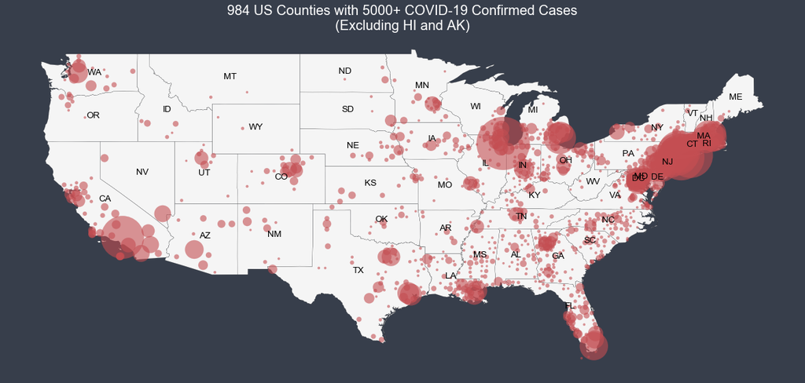

```python
points = us_county_data_geo_df.apply(
    lambda row: Point(row['LON'], row['LAT']), axis=1
)
geo_county_points = gpd.GeoDataFrame(us_county_data_geo_df, geometry=points)
geo_county_points.crs = 'epsg:4326'  # 4269, 9075, 4326
geo_county_points = geo_county_points.sort_values(
    by=['cases'], ascending=False
)

states_gdf = gpd.read_file('states/states.shp')
states_gdf.crs = 'epsg:4326'
count = (
    geo_county_points[geo_county_points['cases'] >= 5000]['county'].count()
)

fig, ax = plt.subplots(figsize=(18, 8))

ax.set_aspect('equal')
ax.set_title(
    f"{count} US Counties with 5000+ COVID-19 Confirmed Cases\n"
    f"(Excluding HI and AK)", fontsize=20, color='w'
)
ax.set_axis_off()

(
    states_gdf[(states_gdf['STATE_NAME'] != 'Alaska') &
               (states_gdf['STATE_NAME'] != 'Hawaii')]
    .plot(ax=ax, color='whitesmoke', edgecolor='black')
)
for idx, row in (
    states_gdf[(states_gdf['STATE_NAME'] != 'Alaska') &
               (states_gdf['STATE_NAME'] != 'Hawaii')].iterrows()
):
    ax.annotate(
        s=row['STATE_ABBR'], xy=(row['geometry'].centroid.coords.xy[0][0],
                                 row['geometry'].centroid.coords.xy[1][0]),
        ha='center', color='black'
    )
geo_county_points[geo_county_points['cases'] >= 5000].plot(
    ax=ax, color='r', alpha=0.6, markersize=geo_county_points['cases'] / 500
)
plt.tight_layout()
plt.show()
```

**Plot differnce between cases reported -1 day**

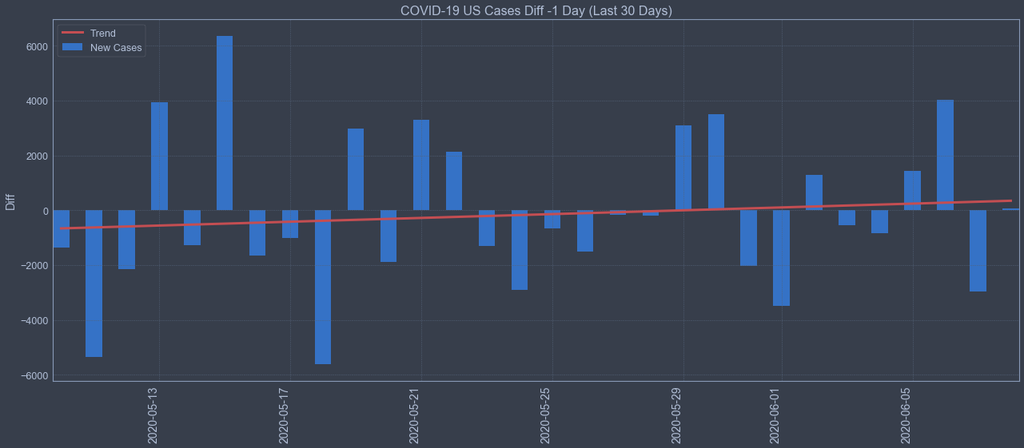

```python
n_days = 30
y = np.array(
    covid_data_df[covid_data_df['countriesAndTerritories'] ==
                  'USA']['cases'][:n_days+1].diff(periods=-1)[0:-1]
)

x = np.array(
    covid_data_df[covid_data_df['countriesAndTerritories'] == 'USA']
    ['dateRep'][:n_days]
)
z = np.polyfit(np.arange(len(x)), y, 1)
p = np.poly1d(z)(np.arange(len(x)))

fig, ax = plt.subplots(figsize=(18, 8))

ax.set_title("COVID-19 US Cases Diff -1 Day (Last 30 Days)", fontsize=16)
ax.set(ylabel="Diff")
plt.xticks(rotation=90, ha='right', fontsize=14)

ax.bar(x, y, width=0.5, label='New Cases')
ax.plot(x, p, color='r', label='Trend', linewidth=3)

ax.legend(loc=2)
ax.grid(linestyle='--', linewidth=0.5)
ax.margins(x=0)
plt.tight_layout()
plt.show()
```

```python
print(f'Report timestamp: {datetime.datetime.now()} US/Pacific')
```

```
Report timestamp: 2020-06-08 13:34:10.174367 US/Pacific
```